# Analysis of yeast protein lengths

Goal of study: Investigate if different families of yeast (Saccharomycetaceae, Debaryomycetaceae) differ in protein lengths. Check differences between enzymatic and non-enzymatic proteins.

```r
library(stringr)
library(lmtest)
```

```r
library(ggplot2)
library(readr)
```

### Data preparation

```r
taxonomy <- data.frame("Species" = c("Candida albicans",
                                          "Meyerozyma guilliermondii",
                                          "Debaryomyces hansenii",
                                          "Candida dubliniensis",
                                          "Babjeviella inositovora",
                                          "Saccharomyces cerevisiae",
                                          "Ashbya gossypii",
                                          "Naumovozyma castellii",
                                          "Kluyveromyces lactis",
                                          "Zygosaccharomyces rouxii"),
                       "Family" = c(rep("Debaryomycetaceae", 5), rep("Saccharomycetaceae", 5)))

protein.files <- list.files("Dane")
protein.data <- read_delim(str_c("Dane/", protein.files[1]), "\t", escape_double = FALSE, trim_ws = TRUE)
for(prot.file in protein.files[-1]){
  protein.data <- suppressMessages(rbind(protein.data, read_delim(str_c("Dane/", prot.file), "\t", escape_double = FALSE, trim_ws = TRUE)))
}

protein.data$Organism <- sapply(protein.data$Organism, function(org) str_c(str_split(org, fixed(" "))[[1]][1:2], collapse=" "))
# check for proper name parsing:
# unique(protein.data$Organism) %in% taxonomy$Species

protein.data$Organism_family <- sapply(protein.data$Organism, function(org) as.character(taxonomy[which(taxonomy$Species==org), 2]))
# check for proper parsing
# unique(protein.data$Organism_family)

protein.data$Log.length <- log(protein.data$Length)
# Normalized lengths for testing purposes
protein.data$Normalized.log <- unlist(tapply(protein.data$Log.length, protein.data$Organism, function(x) x-mean(x)))
protein.data$Normalized.log <- unlist(tapply(protein.data$Normalized.log, protein.data$Organism, function(x) x/sd(x)))

protein.data$Protein.type <- ifelse(is.na(protein.data$`EC number`), "Non-enzymatic", "Enzymatic")
names(protein.data)
```

```
##  [1] "Entry"                     "Entry name"
##  [3] "Status"                    "Protein names"
##  [5] "Gene names"                "Organism"
##  [7] "Length"                    "Catalytic activity"
##  [9] "Pathway"                   "EC number"
## [11] "Subcellular location [CC]" "Organism_family"
## [13] "Log.length"                "Normalized.log"
## [15] "Protein.type"
```

```r
protein.data[1, ]
```

```
## # A tibble: 1 × 15
##        Entry     `Entry name`     Status
##        <chr>            <chr>      <chr>
## 1 A0A1E3QMC0 A0A1E3QMC0_9ASCO unreviewed
## # ... with 12 more variables: `Protein names` <chr>, `Gene names` <chr>,
## #   Organism <chr>, Length <int>, `Catalytic activity` <chr>,
## #   Pathway <chr>, `EC number` <chr>, `Subcellular location [CC]` <chr>,
## #   Organism_family <chr>, Log.length <dbl>, Normalized.log <dbl>,
## #   Protein.type <chr>
```

### Data visualisation

```r
suppressMessages(tapply(protein.data$Normalized.log, protein.data$Organism, ks.test, pnorm))
```

```
## $`Ashbya gossypii`
##
##  One-sample Kolmogorov-Smirnov test
##
## data:  X[[i]]
## D = 0.039236, p-value = 8.631e-07
## alternative hypothesis: two-sided
##
##
## $`Babjeviella inositovora`
##
##  One-sample Kolmogorov-Smirnov test
##
## data:  X[[i]]
## D = 0.047756, p-value = 4.317e-13
## alternative hypothesis: two-sided
##
##
## $`Candida albicans`
##
##  One-sample Kolmogorov-Smirnov test
##
## data:  X[[i]]
## D = 0.043036, p-value = 2.046e-10
## alternative hypothesis: two-sided
##
##
## $`Candida dubliniensis`
##
##  One-sample Kolmogorov-Smirnov test
##
## data:  X[[i]]
## D = 0.060383, p-value < 2.2e-16
## alternative hypothesis: two-sided
##
##
## $`Debaryomyces hansenii`
##
##  One-sample Kolmogorov-Smirnov test
##
```

[output cut: 33 more lines]

```
##
##  One-sample Kolmogorov-Smirnov test
##
## data:  X[[i]]
## D = 0.047207, p-value = 1.862e-13
## alternative hypothesis: two-sided
##
##
## $`Zygosaccharomyces rouxii`
##
##  One-sample Kolmogorov-Smirnov test
##
## data:  X[[i]]
## D = 0.020619, p-value = 0.0288
## alternative hypothesis: two-sided
```

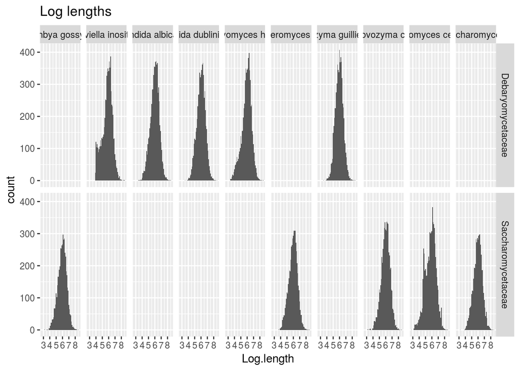

```r
ggplot(data=protein.data) + geom_histogram(aes(x=Log.length), binwidth=0.1) + facet_grid(Organism_family~Organism) + ggtitle("Log lengths")
```

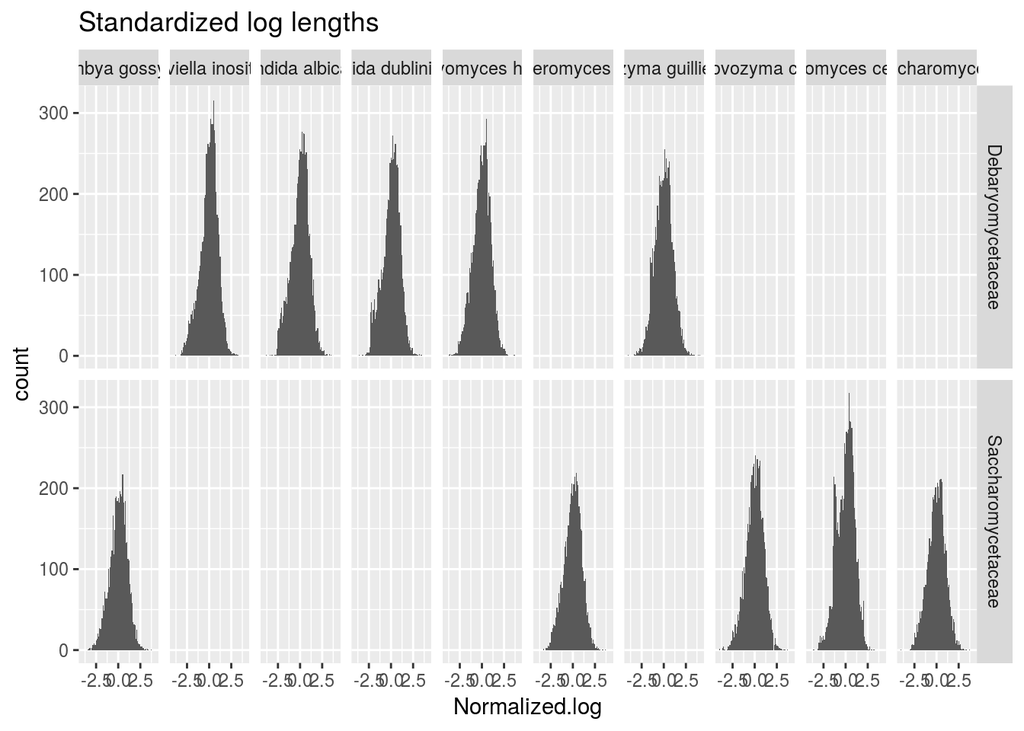

```r
ggplot(data=protein.data) + geom_histogram(aes(x=Normalized.log), binwidth=0.1) + facet_grid(Organism_family~Organism) + ggtitle("Standardized log lengths")
```

The normalized log-lengths are fairly normal.

### Contingency tables

Species vs family table

```r
table(protein.data$Organism, protein.data$Organism_family)
```

```
##
##                             Debaryomycetaceae Saccharomycetaceae
##   Ashbya gossypii                           0               4760
##   Babjeviella inositovora                6394                  0
##   Candida albicans                       6210                  0
##   Candida dubliniensis                   5829                  0
##   Debaryomyces hansenii                  6285                  0
##   Kluyveromyces lactis                      0               5071
##   Meyerozyma guilliermondii              5920                  0
##   Naumovozyma castellii                     0               5565
##   Saccharomyces cerevisiae                  0               6732
##   Zygosaccharomyces rouxii                  0               4987
```

The nested structure is clearly visible. However, since the species names are unique in families, crossed analysis is the same as nested analysis.

Species vs protein type table

```r
table(protein.data$Organism, protein.data$Protein.type)
```

```
##
##                             Enzymatic Non-enzymatic
##   Ashbya gossypii                 545          4215
##   Babjeviella inositovora         399          5995
##   Candida albicans                686          5524
##   Candida dubliniensis           1328          4501
##   Debaryomyces hansenii           560          5725
##   Kluyveromyces lactis            573          4498
##   Meyerozyma guilliermondii       441          5479
##   Naumovozyma castellii           412          5153
##   Saccharomyces cerevisiae       1755          4977
##   Zygosaccharomyces rouxii        391          4596
```

The structure is clearly crossed, because proteins of each type are found in all species. However, the groups are highly unbalanced.

### ANOVA analysis

##### Nested analysis of differences among organisms:

```r
taxonomic.model <- lm(Log.length ~ Organism_family + Organism:Organism_family, data=protein.data)
taxonomic.anova <- anova(taxonomic.model)
taxonomic.anova
```

```
## Analysis of Variance Table
##
## Response: Log.length
##                             Df  Sum Sq Mean Sq F value Pr(>F)
## Organism_family              1     0.0   0.014  0.0276  0.868
## Organism_family:Organism     8   396.1  49.513 94.4466 <2e-16 ***
## Residuals                57743 30271.2   0.524
## ---
## Signif. codes:  0 '***' 0.001 '**' 0.01 '*' 0.05 '.' 0.1 ' ' 1
```

There are no significant differences between the families, but significant differences between the organisms within the families.

```r
taxonomic.model$coefficients
```

```
##                                                         (Intercept)
##                                                         5.957049926
##                                   Organism_familySaccharomycetaceae
##                                                         0.003973946
##    Organism_familyDebaryomycetaceae:OrganismBabjeviella inositovora
##                                                        -0.180262667
##   Organism_familySaccharomycetaceae:OrganismBabjeviella inositovora
##                                                                  NA
##           Organism_familyDebaryomycetaceae:OrganismCandida albicans
##                                                         0.024740856
##          Organism_familySaccharomycetaceae:OrganismCandida albicans
##                                                                  NA
##       Organism_familyDebaryomycetaceae:OrganismCandida dubliniensis
##                                                         0.055761191
##      Organism_familySaccharomycetaceae:OrganismCandida dubliniensis
##                                                                  NA
##      Organism_familyDebaryomycetaceae:OrganismDebaryomyces hansenii
##                                                        -0.048551598
##     Organism_familySaccharomycetaceae:OrganismDebaryomyces hansenii
##                                                                  NA
##       Organism_familyDebaryomycetaceae:OrganismKluyveromyces lactis
##                                                                  NA
##      Organism_familySaccharomycetaceae:OrganismKluyveromyces lactis
##                                                        -0.001973792
##  Organism_familyDebaryomycetaceae:OrganismMeyerozyma guilliermondii
##                                                                  NA
## Organism_familySaccharomycetaceae:OrganismMeyerozyma guilliermondii
##                                                                  NA
##      Organism_familyDebaryomycetaceae:OrganismNaumovozyma castellii
##                                                                  NA
##     Organism_familySaccharomycetaceae:OrganismNaumovozyma castellii
##                                                         0.023417294
##   Organism_familyDebaryomycetaceae:OrganismSaccharomyces cerevisiae
##                                                                  NA
##  Organism_familySaccharomycetaceae:OrganismSaccharomyces cerevisiae
##                                                        -0.178887433
##   Organism_familyDebaryomycetaceae:OrganismZygosaccharomyces rouxii
##                                                                  NA
##  Organism_familySaccharomycetaceae:OrganismZygosaccharomyces rouxii
##                                                         0.016544404
```

On average, proteins of the Saccharomycetaceae family turned out to be `exp(0.003973946) = 1.004` times longer than proteins of Debaryomycetaceae (as the effects of coefficients are multiplicative after taking an exponent); This difference is not significant.

```r
coeftest(taxonomic.model)
```

```
##
## t test of coefficients:
##
##                                                                      Estimate
## (Intercept)                                                         5.9570499
## Organism_familySaccharomycetaceae                                   0.0039739
## Organism_familyDebaryomycetaceae:OrganismBabjeviella inositovora   -0.1802627
## Organism_familyDebaryomycetaceae:OrganismCandida albicans           0.0247409
## Organism_familyDebaryomycetaceae:OrganismCandida dubliniensis       0.0557612
## Organism_familyDebaryomycetaceae:OrganismDebaryomyces hansenii     -0.0485516
## Organism_familySaccharomycetaceae:OrganismKluyveromyces lactis     -0.0019738
## Organism_familySaccharomycetaceae:OrganismNaumovozyma castellii     0.0234173
## Organism_familySaccharomycetaceae:OrganismSaccharomyces cerevisiae -0.1788874
## Organism_familySaccharomycetaceae:OrganismZygosaccharomyces rouxii  0.0165444
##                                                                    Std. Error
## (Intercept)                                                         0.0094103
## Organism_familySaccharomycetaceae                                   0.0140957
## Organism_familyDebaryomycetaceae:OrganismBabjeviella inositovora    0.0130592
## Organism_familyDebaryomycetaceae:OrganismCandida albicans           0.0131519
## Organism_familyDebaryomycetaceae:OrganismCandida dubliniensis       0.0133600
## Organism_familyDebaryomycetaceae:OrganismDebaryomyces hansenii      0.0131136
## Organism_familySaccharomycetaceae:OrganismKluyveromyces lactis      0.0146121
## Organism_familySaccharomycetaceae:OrganismNaumovozyma castellii     0.0142947
## Organism_familySaccharomycetaceae:OrganismSaccharomyces cerevisiae  0.0137116
## Organism_familySaccharomycetaceae:OrganismZygosaccharomyces rouxii  0.0146716
##                                                                     t value
## (Intercept)                                                        633.0338
## Organism_familySaccharomycetaceae                                    0.2819
## Organism_familyDebaryomycetaceae:OrganismBabjeviella inositovora   -13.8035
## Organism_familyDebaryomycetaceae:OrganismCandida albicans            1.8812
## Organism_familyDebaryomycetaceae:OrganismCandida dubliniensis        4.1737
## Organism_familyDebaryomycetaceae:OrganismDebaryomyces hansenii      -3.7024
## Organism_familySaccharomycetaceae:OrganismKluyveromyces lactis      -0.1351
## Organism_familySaccharomycetaceae:OrganismNaumovozyma castellii      1.6382
## Organism_familySaccharomycetaceae:OrganismSaccharomyces cerevisiae -13.0464
## Organism_familySaccharomycetaceae:OrganismZygosaccharomyces rouxii   1.1276
##                                                                     Pr(>|t|)
## (Intercept)                                                        < 2.2e-16
## Organism_familySaccharomycetaceae                                  0.7780011
## Organism_familyDebaryomycetaceae:OrganismBabjeviella inositovora   < 2.2e-16
## Organism_familyDebaryomycetaceae:OrganismCandida albicans          0.0599552
## Organism_familyDebaryomycetaceae:OrganismCandida dubliniensis      3.001e-05
## Organism_familyDebaryomycetaceae:OrganismDebaryomyces hansenii     0.0002138
## Organism_familySaccharomycetaceae:OrganismKluyveromyces lactis     0.8925500
## Organism_familySaccharomycetaceae:OrganismNaumovozyma castellii    0.1013889
## Organism_familySaccharomycetaceae:OrganismSaccharomyces cerevisiae < 2.2e-16
## Organism_familySaccharomycetaceae:OrganismZygosaccharomyces rouxii 0.2594733
##
## (Intercept)                                                        ***
## Organism_familySaccharomycetaceae
## Organism_familyDebaryomycetaceae:OrganismBabjeviella inositovora   ***
## Organism_familyDebaryomycetaceae:OrganismCandida albicans          .
## Organism_familyDebaryomycetaceae:OrganismCandida dubliniensis      ***
## Organism_familyDebaryomycetaceae:OrganismDebaryomyces hansenii     ***
## Organism_familySaccharomycetaceae:OrganismKluyveromyces lactis
## Organism_familySaccharomycetaceae:OrganismNaumovozyma castellii
## Organism_familySaccharomycetaceae:OrganismSaccharomyces cerevisiae ***
## Organism_familySaccharomycetaceae:OrganismZygosaccharomyces rouxii
## ---
## Signif. codes:  0 '***' 0.001 '**' 0.01 '*' 0.05 '.' 0.1 ' ' 1
```

There are three species with p-value lower than `10^-4`: Babjeviella inositovora, Candida dubliniensis and Saccharomyces cerevisiae (Debaryomyces hansenii has a higher p-value and low estimate, so it’s less interesting). The species with the biggest magnitude of estimate are Babjeviella inositovora and Saccharimyces cerevisiae.

The mean length of Saccharomycetaceae proteins is `exp(5.957049926+0.003973946) = 388.0072`; Saccharomyces cerevisiae species have proteins shorter by a factor of `exp(-0.178887433) = 0.8362`, giving average length of `exp(5.957049926+0.003973946-0.178887433)=324.4516`, i.e. over 60 aminoacids shorter than the mean for Saccharomecetacea. This suggests presence of an evolutionary pressure on this organism to shorten its proteins.

The average length of proteins of Babjeviella inositovora is `exp(5.9570499-0.1802627)=322.7207`.

##### Crossed analysis of differences among protein types:

```r
enzyme.model <- lm(Log.length ~ Organism*Protein.type, data=protein.data)
enzyme.anova <- anova(enzyme.model)
enzyme.anova
```

```
## Analysis of Variance Table
##
## Response: Log.length
##                          Df  Sum Sq Mean Sq F value    Pr(>F)
## Organism                  9   396.1   44.01  85.644 < 2.2e-16 ***
## Protein.type              1   445.3  445.30 866.501 < 2.2e-16 ***
## Organism:Protein.type     9   156.5   17.39  33.837 < 2.2e-16 ***
## Residuals             57733 29669.4    0.51
## ---
## Signif. codes:  0 '***' 0.001 '**' 0.01 '*' 0.05 '.' 0.1 ' ' 1
```

There are significant differences between the protein types, and an interaction with organism species.

```r
enzyme.model$coefficients
```

```
##                                                 (Intercept)
##                                                6.1294388699
##                             OrganismBabjeviella inositovora
##                                               -0.0233348580
##                                    OrganismCandida albicans
##                                                0.0314476630
##                                OrganismCandida dubliniensis
##                                               -0.0051970919
##                               OrganismDebaryomyces hansenii
##                                               -0.0078030708
##                                OrganismKluyveromyces lactis
##                                                0.0002517145
##                           OrganismMeyerozyma guilliermondii
##                                               -0.0202126828
##                               OrganismNaumovozyma castellii
##                                                0.0057632684
##                            OrganismSaccharomyces cerevisiae
##                                                0.0714431757
##                            OrganismZygosaccharomyces rouxii
##                                               -0.0148303505
##                                   Protein.typeNon-enzymatic
##                                               -0.1901910773
##   OrganismBabjeviella inositovora:Protein.typeNon-enzymatic
##                                               -0.1610435048
##          OrganismCandida albicans:Protein.typeNon-enzymatic
##                                               -0.0111457462
##      OrganismCandida dubliniensis:Protein.typeNon-enzymatic
##                                                0.0458832959
##     OrganismDebaryomyces hansenii:Protein.typeNon-enzymatic
##                                               -0.0437947762
##      OrganismKluyveromyces lactis:Protein.typeNon-enzymatic
##                                               -0.0021873125
## OrganismMeyerozyma guilliermondii:Protein.typeNon-enzymatic
##                                                0.0257662792
##     OrganismNaumovozyma castellii:Protein.typeNon-enzymatic
##                                                0.0273762485
##  OrganismSaccharomyces cerevisiae:Protein.typeNon-enzymatic
##                                               -0.3762134692
##  OrganismZygosaccharomyces rouxii:Protein.typeNon-enzymatic
##                                                0.0414922749
```

```r
scer.enz.mean <- exp(6.1294388699 + 0.0714431757)
scer.nonenz.mean <- exp(6.1294388699 + 0.0714431757 - 0.3762134692 -0.1901910773)
real.scer.enz.mean <- mean(protein.data[protein.data$Organism=="Saccharomyces cerevisiae" & protein.data$Protein.type=="Enzymatic", ]$Length)
real.scer.nonenz.mean <- mean(protein.data[protein.data$Organism=="Saccharomyces cerevisiae" & protein.data$Protein.type=="Non-enzymatic", ]$Length)
```

The predicted mean protein length for Saccharomyces cerevisiae non-enzymatic proteins is 279.9126245, and for S. cerevisiae enzymatic proteins is 493.18386. The exponent of interaction coefficient is equal to `exp(-0.3762134692)=0.6865`, which means that on average, a non-enzymatic protein from S.cerevisiae will be about 0.7 times shorter that it would be expected if the effects were strictily additive. This means that the evolutionary pressure on this yeast to shorten its non-enzymatic proteins is stronger that the pressure to shorten the enzymatic proteins, and/or that the pressure to shorten non-enzymatic proteins is stronger in this organism compared to other species.

The obtained estimates deviate highly from the ones computed by hand: 398.5810729 for non-enzymatic and 594.1019943 for enzymatic S. cerevisiae proteins. I don’t understand this effect. Is this a result of stabilization of variance in a hierarchical model?

##### Full model

```r
full.model <- lm(Log.length ~ Organism_family + Protein.type + Organism + Organism:Protein.type + Organism:Organism_family, data=protein.data)
full.anova <- anova(full.model)
full.anova
```

```
## Analysis of Variance Table
##
## Response: Log.length
##                          Df  Sum Sq Mean Sq  F value Pr(>F)
## Organism_family           1     0.0    0.01   0.0282 0.8667
## Protein.type              1   395.2  395.17 768.9475 <2e-16 ***
## Organism                  8   446.2   55.78 108.5398 <2e-16 ***
## Protein.type:Organism     9   156.5   17.39  33.8369 <2e-16 ***
## Residuals             57733 29669.4    0.51
## ---
## Signif. codes:  0 '***' 0.001 '**' 0.01 '*' 0.05 '.' 0.1 ' ' 1
```

```r
full.model$coefficients
```

```
##                                                         (Intercept)
##                                                        6.1092261871
##                                   Organism_familySaccharomycetaceae
##                                                        0.0202126828
##                                           Protein.typeNon-enzymatic
##                                                       -0.1901910773
##                                     OrganismBabjeviella inositovora
##                                                       -0.0031221752
##                                            OrganismCandida albicans
##                                                        0.0516603458
##                                        OrganismCandida dubliniensis
##                                                        0.0150155910
##                                       OrganismDebaryomyces hansenii
##                                                        0.0124096120
##                                        OrganismKluyveromyces lactis
##                                                        0.0002517145
##                                   OrganismMeyerozyma guilliermondii
##                                                                  NA
##                                       OrganismNaumovozyma castellii
##                                                        0.0057632684
##                                    OrganismSaccharomyces cerevisiae
##                                                        0.0714431757
##                                    OrganismZygosaccharomyces rouxii
##                                                       -0.0148303505
##           Protein.typeNon-enzymatic:OrganismBabjeviella inositovora
##                                                       -0.1610435048
##                  Protein.typeNon-enzymatic:OrganismCandida albicans
##                                                       -0.0111457462
##              Protein.typeNon-enzymatic:OrganismCandida dubliniensis
##                                                        0.0458832959
##             Protein.typeNon-enzymatic:OrganismDebaryomyces hansenii
##                                                       -0.0437947762
##              Protein.typeNon-enzymatic:OrganismKluyveromyces lactis
##                                                       -0.0021873125
##         Protein.typeNon-enzymatic:OrganismMeyerozyma guilliermondii
##                                                        0.0257662792
##             Protein.typeNon-enzymatic:OrganismNaumovozyma castellii
##                                                        0.0273762485
##          Protein.typeNon-enzymatic:OrganismSaccharomyces cerevisiae
##                                                       -0.3762134692
##          Protein.typeNon-enzymatic:OrganismZygosaccharomyces rouxii
##                                                        0.0414922749
##   Organism_familySaccharomycetaceae:OrganismBabjeviella inositovora
##                                                                  NA
##          Organism_familySaccharomycetaceae:OrganismCandida albicans
##                                                                  NA
##      Organism_familySaccharomycetaceae:OrganismCandida dubliniensis
##                                                                  NA
##     Organism_familySaccharomycetaceae:OrganismDebaryomyces hansenii
##                                                                  NA
##      Organism_familySaccharomycetaceae:OrganismKluyveromyces lactis
##                                                                  NA
## Organism_familySaccharomycetaceae:OrganismMeyerozyma guilliermondii
##                                                                  NA
##     Organism_familySaccharomycetaceae:OrganismNaumovozyma castellii
##                                                                  NA
##  Organism_familySaccharomycetaceae:OrganismSaccharomyces cerevisiae
##                                                                  NA
##  Organism_familySaccharomycetaceae:OrganismZygosaccharomyces rouxii
##                                                                  NA
```